# Examples of 3-D classifications using Linear Discriminant Analysis with uniform spherical distributions

The LDA method is applied to a dataset made from two uniform spherical probability distribution functions (PDF) weighted with their *a priori* class probabilities $P(C_{i})$:

> $P(\bf{x}) = P(\bf{x}|C_{1}) P(C_{1}) + P(\bf{x}|C_{2}) P(C_{2})$

Discriminant methods are used to locate the influence zone(s) of each data cluster *$\bf{i}$* over a spatial grid. This corresponds to regions where

> $P(\bf{x}|C_{i}) P(C_{i}) > P(\bf{x}|C_{j \ne i}) P(C_{j \ne i})$

or

> $h_{i}(\bf{x}) > h_{j \ne i}(\bf{x})$

with the discriminant function $h_{i}(\bf{x})$ defined as

> $h_{i}(\bf{x}) = \ln P(\bf{x}|C_{i}) P(C_{i})$

## Linear Discriminant Analysis

The LDA method is a special case of the quadratic discriminant analysis (QDA) method where

> $h_{i}(\bf{x}) =\frac{1}{2}\ln |\Sigma_{i}| -\frac{1}{2}(\bf{x}-\bf{\mu_{i}})^\top \Sigma_{i}^{-1} (\bf{x}-\bf{\mu_{i}}) + \ln P(C_{i})$

with

> The observation: $\bf{x}=[x_{1} x_{2} x_{3}]^\top$

> The origin: $\bf{\mu_{i}} = [\mu_{1} \mu_{2} \mu_{3}]^\top$

> The covariance matrix: $\bf{\Sigma_{i}} = \begin{pmatrix} \sigma_{x_{1}}^2 & \sigma_{x_{1,2}} & \sigma_{x_{1,3}} \\ \sigma_{x_{2,1}} & \sigma_{x_{2}}^2 & \sigma_{x_{2,3}} \\ \sigma_{x_{3,1}} & \sigma_{x_{3,2}} & \sigma_{x_{3}}^2 \end{pmatrix}$

In the LDA method, we assume the same covariance matrix for all classes. It is computed as a weighted mixture of the individual matrices:

> $\Sigma = \sum_{i=0}^{N} P(C_{i}) \Sigma_{i}$

Using this simplifying assumption, the LDA discriminant equation reduces to (after dropping terms that do not depend on class):

> $h_{i}(\bf{x}) = \bf{\mu_{i}}^\top \Sigma^{-1} \bf{x} - \frac{1}{2}\bf{\mu_{i}}^\top \Sigma^{-1} \bf{\mu_{i}} + \ln P(C_{i})$

which is a linear equation! Hence, the LDA method separates data clusters with planar boundaries whereas the QDA involves more complex quadratic boundaries.

We will show how the planar boundary between clusters move in space when their *a priori* class probabilities $P(C_{i})$ are changed. Even if the cluster shapes and positions are fixed, they produce different effects locally as they contain different number of perturbing elements, the data points.

```python
print(__doc__)

# Author: Pierre Gravel <pierre.gravel@iid.ulaval.ca>
# License: BSD


%matplotlib inline

import numpy as np
import matplotlib.pyplot as plt
from matplotlib.colors import ListedColormap
from matplotlib import colors
from mpl_toolkits.mplot3d import Axes3D

from sklearn.discriminant_analysis import LinearDiscriminantAnalysis

from skimage.measure import marching_cubes_lewiner

import math

import seaborn as sns
sns.set(color_codes=True)
```

```
Automatically created module for IPython interactive environment
```

# Part I: Detailed example of two uniform spherical distributions with classification results

The spherical distributions may have different radii and number of data points.

```python
# Used for reproductibility of the results
np.random.seed(42)

# Center of each spherical data cluster
Mu = np.zeros((2,3))
Mu[0,:] = [5., 3., 3.]
Mu[1,:] = [5., 7., 7.]

radius = np.array([2., 2.])

# A priori class probabilities
prob_C = np.array([0.5, 0.5])

x_min, x_max = 0., 10.
y_min, y_max = 0., 10.
z_min, z_max = 0., 10.

view = [30, -26]
npts = 5000
```

Function that generates a dataset with an uniform spherical distribution.

```python
def make_spherical_distribution(r, mu, n):

    phi = np.random.uniform(0,2*math.pi, n)
    costheta = np.random.uniform(-1,1, n)
    u = np.random.uniform(0,1, n)

    theta = np.arccos( costheta )
    r =  r * np.cbrt( u )

    x =  mu[0] + r * np.sin( theta) * np.cos( phi )
    y =  mu[1] + r * np.sin( theta) * np.sin( phi )
    z =  mu[2] + r * np.cos( theta )

    X = np.c_[x.ravel(), y.ravel(), z.ravel()]

    return X
```

Generate a dataset containing two uniform spherical distributions.

```python
n = ( npts*prob_C).astype(int)

X0 = make_spherical_distribution(radius[0], Mu[0,:], n[0])
y0 = np.zeros(n[0])

X1 = make_spherical_distribution(radius[1], Mu[1,:], n[1])
y1 = np.ones(n[1])

X = np.r_[ X0, X1]
y = np.r_[ y0, y1]
```

Display the dataset

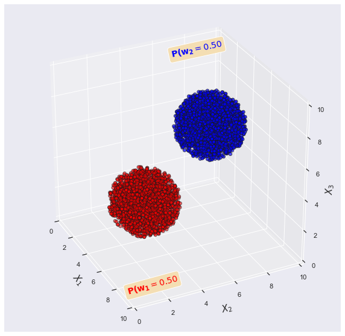

```python
cm_bright = ListedColormap(['#FF0000', '#00FF00', '#0000FF'])

fig = plt.figure(figsize = (10,10))
fig.canvas.set_window_title('3D')
ax = fig.gca(projection='3d')

ax.scatter( X[:, 0],  X[:, 1],  X[:, 2], s=30, c= y, cmap=cm_bright, edgecolors='k')
ax.view_init(view[0], view[1])

ax.set_xlim3d( x_min,  x_max)
ax.set_ylim3d( y_min,  y_max)
ax.set_zlim3d( z_min,  z_max)
ax.set_xlabel('$X_{1}$', fontsize=15)
ax.set_ylabel('$X_{2}$', fontsize=15)
ax.set_zlabel('$X_{3}$', fontsize=15)
ax.yaxis.set_label_coords(-0.1,0.5)
ax.xaxis.set_label_coords(0.5, -0.1)

props = dict(boxstyle='round', facecolor='wheat', alpha=0.99)
texte1 = '$\mathbf{P(w_{1}} = %0.2f$' %  prob_C[0]
texte2 = '$\mathbf{P(w_{2}} = %0.2f$' %  prob_C[1]
ax.text(9.0, 0.0, 0., texte1, zdir='y', fontsize=14, bbox=props, color='red')
ax.text(0.0, 7.0, 9., texte2, zdir='y', fontsize=14, bbox=props, color='blue')

plt.show()
```

Generate a 3-D spatial grid where the PDF will be evaluated locally.

```python
nx, ny, nz = 50, 50, 50
xx,  yy,  zz = np.meshgrid(np.linspace( x_min,  x_max,  nx),
                           np.linspace( y_min,  y_max,  ny),
                           np.linspace( z_min,  z_max,  nz))
Xgrid = np.c_[ xx.ravel(),  yy.ravel(),  zz.ravel()]

# Grid spacings
dx = ( x_max -  x_min)/( nx-1)
dy = ( y_max -  y_min)/( ny-1)
dz = ( z_max -  z_min)/( nz-1)
```

Using Linear discriminant analysis, get the local probability for class 1

```python
# Linear discriminant analysis (LDA)
lda = LinearDiscriminantAnalysis(solver="svd", store_covariance=True)
prob = lda.fit( X,  y).predict_proba(Xgrid)

# Get class 1 probability
prob = prob[:,1]
prob = prob.reshape(xx.shape)
```

Display the planar boundary between both spherical distributions

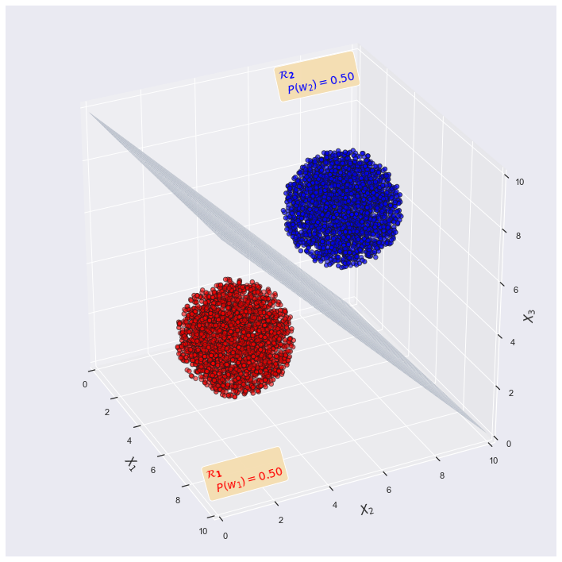

```python
fig = plt.figure(figsize = (10,10))
fig.canvas.set_window_title('3D')
ax = fig.gca(projection='3d')

# Display the data points
ax.scatter( X[:, 0],  X[:, 1],  X[:, 2], s=30, c= y, cmap=cm_bright, edgecolors='k')


# Display the 3-D boundary separating the two data clusters. The boundary is located where the a posteriori
# probabilities for both classes are identical, i.e. P(x|Ci)=0.5
prob = np.transpose( prob, (1, 0, 2))
verts, faces, _, _ = marching_cubes_lewiner( prob, 0.5, spacing=( dy,  dx,  dz))
ax.plot_trisurf(verts[:, 0], verts[:,1], faces, verts[:, 2], alpha=0.5, edgecolor='w', linewidth=0.2, antialiased=True)

ax.view_init(view[0], view[1])

ax.set_xlim3d( x_min,  x_max)
ax.set_ylim3d( y_min,  y_max)
ax.set_zlim3d( z_min,  z_max)
ax.set_xlabel('$X_{1}$', rotation=0, fontsize=15)
ax.set_ylabel('$X_{2}$', fontsize=15)
ax.set_zlabel('$X_{3}$', fontsize=15)
ax.yaxis.set_label_coords(-0.1,0.5)
ax.xaxis.set_label_coords(0.5, -0.1)


# Display class a priori probabilities
props = dict(boxstyle='round', facecolor='wheat', alpha=0.99)
texte1 = '$\mathbf{\mathcal{R}_{1}}$  \n  $P(w_{1}) = %0.2f$' %  prob_C[0]
texte2 = '$\mathbf{\mathcal{R}_{2}}$  \n  $P(w_{2}) = %0.2f$' %  prob_C[1]
ax.text(9.0, 0.0, 0., texte1, zdir='y', fontsize=14, bbox=props, color='red')
ax.text(0.0, 7.0, 9., texte2, zdir='y', fontsize=14, bbox=props, color='blue')


fig.tight_layout()

plt.savefig("3D_LDA_classification_0.50.png")
plt.savefig("3D_LDA_classification_0.50.pdf")

plt.show()
```

# Part II: Various examples of 3-D LDA segmentation of two uniform spherical distributions.

The following function contains most of the code in the previous cells; we use it to display the classification results for each example.

```python
def generate_3D_LDA_segmentation(r, Mu, n, prob_C, x_min, x_max, y_min, y_max, z_min, z_max, figName, view=[15, -20]):

    # Number of data points in each cluster
    n = ( npts*prob_C).astype(int)

    # --------- Generate uniform spherical distributions-----
    for i in range(2):
        phi = np.random.uniform(0,2*math.pi, n[i])
        costheta = np.random.uniform(-1,1, n[i])
        u = np.random.uniform(0,1, n[i])

        theta = np.arccos( costheta )
        radius =  r[i] * np.cbrt( u )

        xi =  Mu[i,0] + radius * np.sin( theta) * np.cos( phi )
        yi =  Mu[i,1] + radius * np.sin( theta) * np.sin( phi )
        zi =  Mu[i,2] + radius * np.cos( theta )

        if (i==0):
            X = np.c_[xi.ravel(), yi.ravel(), zi.ravel()]
            y = np.zeros(n[0])
        else:
            X = np.r_[X, np.c_[xi.ravel(), yi.ravel(), zi.ravel()]]
            y = np.r_[y, np.ones(n[i])]


    # --------- Generate a 3-D spatial grid where the PDF will be evaluated locally --------
    nx, ny, nz = 50, 50, 50
    xx,  yy,  zz = np.meshgrid(np.linspace( x_min,  x_max,  nx),
                               np.linspace( y_min,  y_max,  ny),
                               np.linspace( z_min,  z_max,  nz))
    Xgrid = np.c_[ xx.ravel(),  yy.ravel(),  zz.ravel()]

    # Grid spacings
    dx = ( x_max -  x_min)/( nx-1)
    dy = ( y_max -  y_min)/( ny-1)
    dz = ( z_max -  z_min)/( nz-1)


    # ---------- Using Linear discriminant analysis (LDA), get the local probability for class 1 -----------
    lda = LinearDiscriminantAnalysis(solver="svd", store_covariance=True)
    prob = lda.fit(X, y).predict_proba(Xgrid)

    # Get class 1 probability
    prob = prob[:,1]
    prob = prob.reshape(xx.shape)


    # --------- Display the planar boundary between both spherical distributions -----
    fig = plt.figure(figsize = (10,10))
    fig.canvas.set_window_title('3D')
    ax = fig.gca(projection='3d')

    # Display the data points
    ax.scatter( X[:, 0],  X[:, 1],  X[:, 2], s=30, c= y, cmap=cm_bright, edgecolors='k')


    # Display the 3-D boundary separating the two data clusters. The boundary is located where the a posteriori
    # probabilities for both classes are identical, i.e. P(x|Ci)=0.5
    prob = np.transpose( prob, (1, 0, 2))
    verts, faces, _, _ = marching_cubes_lewiner( prob, 0.5, spacing=( dy,  dx,  dz))
    ax.plot_trisurf(verts[:, 0], verts[:,1], faces, verts[:, 2], alpha=0.5, edgecolor='w', linewidth=0.2, antialiased=True)

    ax.view_init(view[0], view[1])

    ax.set_xlim3d( x_min,  x_max)
    ax.set_ylim3d( y_min,  y_max)
    ax.set_zlim3d( z_min,  z_max)
    ax.set_xlabel('$X_{1}$', rotation=0, fontsize=15)
    ax.set_ylabel('$X_{2}$', fontsize=15)
    ax.set_zlabel('$X_{3}$', fontsize=15)
    ax.yaxis.set_label_coords(-0.1,0.5)
    ax.xaxis.set_label_coords(0.5, -0.1)

    # Display class a priori probabilities P(Ci)
    props = dict(boxstyle='round', facecolor='wheat', alpha=0.99)
    texte1 = '$\mathbf{\mathcal{R}_{1}}$  \n  $P(w_{1}) = %0.2f$' %  prob_C[0]
    texte2 = '$\mathbf{\mathcal{R}_{2}}$  \n  $P(w_{2}) = %0.2f$' %  prob_C[1]
    ax.text(9.0, 0.0, 0., texte1, zdir='y', fontsize=14, bbox=props, color='red')
    ax.text(0.0, 7.0, 9., texte2, zdir='y', fontsize=14, bbox=props, color='blue')


    fig.tight_layout()

    plt.savefig(figName + '.png')
    plt.savefig(figName + '.pdf')

    plt.show()
```

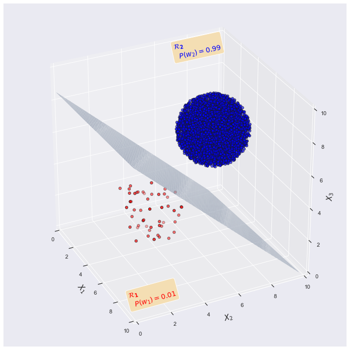

```python
# Used for reproductibility of the results
np.random.seed(42)

# Center of each spherical data cluster
Mu = np.zeros((2,3))
Mu[0,:] = [5., 3., 3.]
Mu[1,:] = [5., 7., 7.]

radius = np.array([2., 2.])

# A priori class probabilities
prob_C = np.array([0.01, 0.99])

x_min, x_max = 0., 10.
y_min, y_max = 0., 10.
z_min, z_max = 0., 10.

view = [30, -26]
npts = 5000

figName= '3D_LDA_classification_0.01'

generate_3D_LDA_segmentation(radius, Mu, npts, prob_C, x_min, x_max, y_min, y_max, z_min, z_max, figName, view=[30, -26])
```

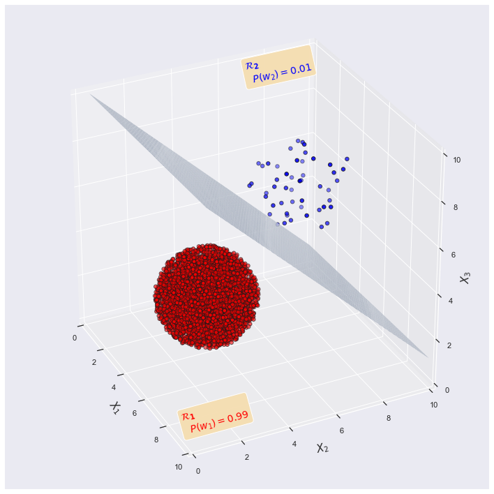

```python
# Used for reproductibility of the results
np.random.seed(42)

# Center of each spherical data cluster
Mu = np.zeros((2,3))
Mu[0,:] = [5., 3., 3.]
Mu[1,:] = [5., 7., 7.]

radius = np.array([2., 2.])

# A priori class probabilities
prob_C = np.array([0.99, 0.01])

x_min, x_max = 0., 10.
y_min, y_max = 0., 10.
z_min, z_max = 0., 10.

view = [30, -26]
npts = 5000


figName= '3D_LDA_classification_0.99'

generate_3D_LDA_segmentation(radius, Mu, npts, prob_C, x_min, x_max, y_min, y_max, z_min, z_max, figName, view=[30, -26])
```